# Naples Reef (January 2010) purple urchins

Eric Shaphran

11/4/2020

### Part 1. Data wrangling

```r
purple_naples <- read_csv(here("data", "urchins.csv")) %>% # Read in urchin data with 'here()'
  clean_names() %>% # Convert column names to lower snake case
  mutate(date_new = mdy(date)) %>% # Convert date column to 'Date' class
  mutate(year = year(date_new)) %>% # Add year column
  mutate(month = month(date_new)) %>% # Add month column
  mutate(site_full = case_when( # Create new column called site_full containing full names of sites
    site == "NAPL" ~ "Naples Reef",
    site == "AQUE" ~ "Arroyo Quemado Reef",
    site == "CARP" ~ "Carpinteria Reef",
    site == "MOHK" ~ "Mohawk Reef",
    site == "IVEE" ~ "Isla Vista Reef"))

purple_naples_2010 <- purple_naples %>% # Start with purple_naples
  filter(site_full == "Naples Reef", common_name == "Purple Urchin", year == 2010, month == 1) # Filter only purple urchins from Naples Reef in January 2010
```

### Part 2. Comparing exploratory graphs

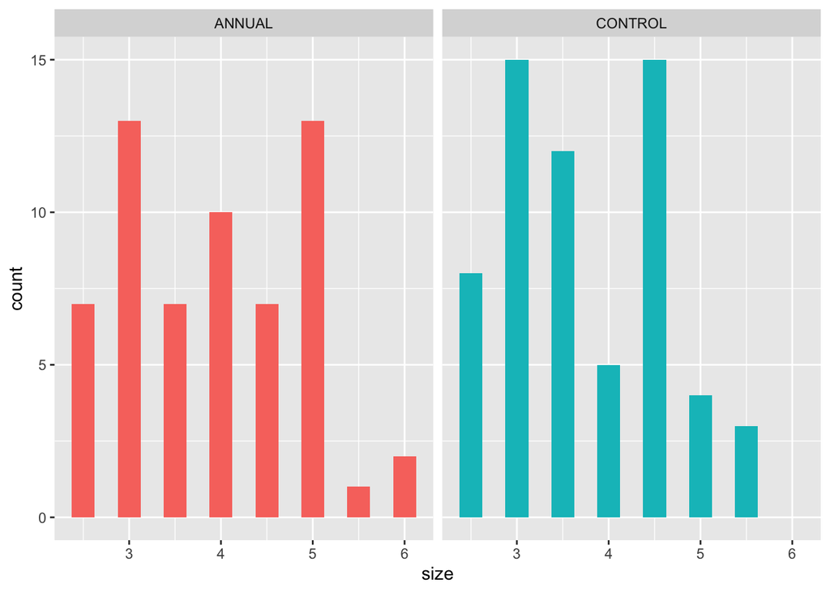

```r
# Histogram comparing treatments
ggplot(data = purple_naples_2010, aes(x = size, fill = treatment)) +
  geom_histogram(bins = 15) +
  theme(legend.position = "none") +
  facet_wrap(~treatment)
```

The urchins in the annual treatment appear to be slightly larger than the urchins in the control group. The urchins from both treatments are similarly distributed but it is hard to establish a normal distribution pattern from the graphs.

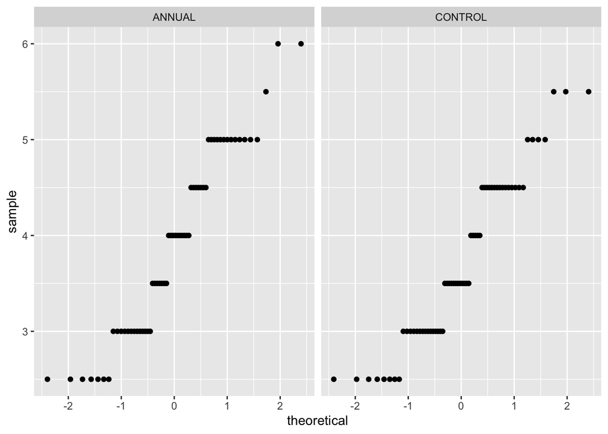

```r
# QQ plot comparing treatments
ggplot(data = purple_naples_2010, aes(sample = size)) +
  geom_qq() +
  facet_wrap(~treatment)
```

Taking into account the fact that the urchin sizes are rounded to the nearest half centimeter, the QQ plots for both treatments appear to be fairly linear and, thus, suggest a normal distribution.

### Part 3. Descriptive statistics

```r
purple_naples_stats <- purple_naples_2010 %>% # Start with purple_naples_2010
  group_by(treatment) %>% # Calculate mean, standard deviation, and sample size for purple_naples_2010
  summarize(mean_urch_size = mean(size),
            sd_urch_size = sd(size),
            n = n())

purple_naples_stats # Show statistics table
```

```
## # A tibble: 2 x 4
##   treatment mean_urch_size sd_urch_size     n
##   <chr>              <dbl>        <dbl> <int>
## 1 ANNUAL              3.92        0.966    60
## 2 CONTROL             3.73        0.867    62
```

### Part 4. Two-sample t-test

```r
annual_sample <- purple_naples_2010 %>%
  filter(treatment == "ANNUAL") %>% # Create vector with observations from annual treatment only
  pull(size)

control_sample <- purple_naples_2010 %>%
  filter(treatment == "CONTROL") %>% # Create vector with observations from control treatment only
  pull(size)

t.test(x = annual_sample, y = control_sample)
```

```
##
##  Welch Two Sample t-test
##
## data:  annual_sample and control_sample
## t = 1.1472, df = 117.66, p-value = 0.2536
## alternative hypothesis: true difference in means is not equal to 0
## 95 percent confidence interval:
##  -0.1386165  0.5203369
## sample estimates:
## mean of x mean of y
##  3.916667  3.725806
```

```r
3.916667-3.725806
```

```
## [1] 0.190861
```

The relatively small difference between the means of the two samples (0.19cm) suggests that the two samples could have been taken from populations with the same mean. However, because the sample sizes are relatively small(60 and 62) and the standard deviations are relatively large (0.97cm and 0.87cm), it is difficult to determine with a high degree of certainty whether the samples were taken from populations with the same mean. The p-value of .2536 means that if both samples came from populations with the exact same mean, then there is a 25.36% chance that two other randomly picked samples could have had means farther apart than 0.19cm from these samples.